# Avoid Bicycle Thefts in Toronto Using Historical Data

Alan Chen

September 27, 2020

**Abstract**

Toronto bicycle route infrastructure is quickly growing, but the city suffers from large cases of bicycle thefts. After making observations on historical bicycle data, we have observed that bicycle theft is very common in Toronto. Despite this, the data has shown that riders should take proactive measures to avoid bike theft such as: registering their bike with the Toronto Police, avoid parking in areas with high theft occurrences such as West Spadina and Yonge/South of Bloor, and properly securing their bike (both wheels and frame) on grounded sturdy objects (eg. bike racks) with appropriate locks (typically using both a U-lock and a heavy duty cable lock), especially in residential areas.

Bike riding is one of the best ways to get around the city for people of all ages. It is eco-friendly, good for cardiovascular health, cheap to maintain and arguably faster than cars and trains under traffic congestion. It is becoming more popular in Toronto, especially in the downtown core. From a 2016 census, the bike riding population has nearly doubled since 2006 and 15 to 30 percent of Torontonians in some downtown neighborhoods bike to work. With a flat grid-like layout and 563km of bicycle routes already constructed, Toronto provides an amazing bike infrastructure and the city is already executing their long term plan to further expand the bike scene with the Ten-Year Cycling Network Plan (2016-2025). This plan has an annual funding of $16 million which is aimed towards creating new bike routes and renewing existing trails to attract more attention to the bike scene and enable more possibilities for riders and delivery businesses to get around the city efficiently.

While it is exciting to see the bike scene rapidly growing, Torontonians, riders and non-riders alike, should understand bicycle safety to avoid accidents and theft. In particular, bicycle thefts have become so common nowadays, a Toronto police officer shares that his division (Division 51) alone gets around 3-4 reports of bicycle thefts per day. Note that this does not include reports in other divisions or incidents that were gone unreported, so this can a major issue that negatively impacts the growth of the bike community. To shed some light about the severity of this issue and tips to avoid it, we will investigate the “Bicycle Thefts” dataset provided by the Open Toronto Data Catalogue (https://open.toronto.ca/dataset/bicycle-thefts/).

As of the date of that this article was written, this dataset contains bicycle theft occurrences in Toronto from 2014-2019 that were reported to Toronto police. It is updated annually by Toronto Police Services. There are over 21584 entries and 26 columns. The data features pertain to the time and setting of the incident, description of the stolen bicycle, and status of the incident. For reproduction purposes, please be advised that downloading the data could take a long time due to the size of the dataset.

To begin, we will first identify the severity of bike thefts in Toronto by looking at the number of occurrences. Based on the number of entries of the dataset, we already know that there have been at least 21584 bike thefts from 2014 to 2019. Even without the unrecorded incidents, this number alone is already quite massive. Furthermore, we can notice an increasing trend on the year-by-year occurrence plot:

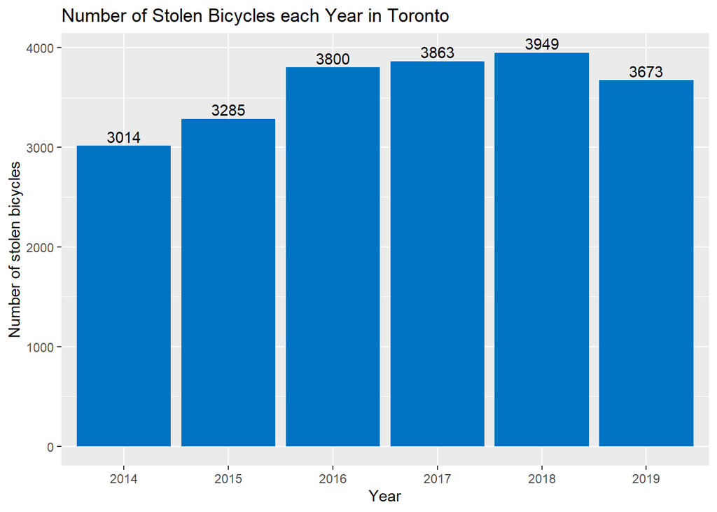

```r
year_df <- df %>%
  group_by(Occurrence_Year) %>%
  count(Occurrence_Year)
year_df$Occurrence_Year <- factor(year_df$Occurrence_Year, levels = year_df$Occurrence_Year[order(year_df$Occurrence_Year)])
ggplot(year_df, aes(x=Occurrence_Year, y=n)) +
  geom_bar(fill = "#0073C2FF", stat = "identity") +
  geom_text(aes(label = n), vjust = -0.3) +
  ggtitle("Number of Stolen Bicycles each Year in Toronto") +
  xlab("Year") + ylab("Number of stolen bicycles")
```

With 3014 occurrences at 2014, we can see that bike theft is already a prominent issue in the city. After a slight increase in 2015, there is a significant jump in the amount of bikes stolen from year 2016 and later. Knowing that the Ten-Year Cycling Network Plan started in 2016, this could have played a factor in the increased bike thefts as more and more people join the bike scene. Years 2017 and 2018 were slight increases from their previous year, with 2018 peaking at 3949 occurrences. This is a 31% increase of incidents since 2014 and this shows that bike stealing is an issue that is consistently getting worse year after year. In 2019, there is some improvement at 3673 cases. This could be explained by the fact that the government has installed over 1400 bike parking stations across the city for riders to safely secure their bicycles. While the number of occurrences is still large, it is good to see that the government is being proactive to prevent bikes from being stolen. Nevertheless, riders themselves should still be taking proactive measures to ensure bike security.

### Registry is key

The first proactive measure is to keep note of the bike’s serial number and register the bicycle with the Toronto Police. This way, the police is able to find the owner of the bike in the event that a stolen bike is recovered and the owner is also able to justify their ownership. Since thieves tend to steal bikes with the motive of selling them online or to retail stores, it is likely that the original owner can recover their bike without any uncertainty with help of the police and the bike registry. However, we see that the recovery rate of stolen bikes is quite low in the dataset:

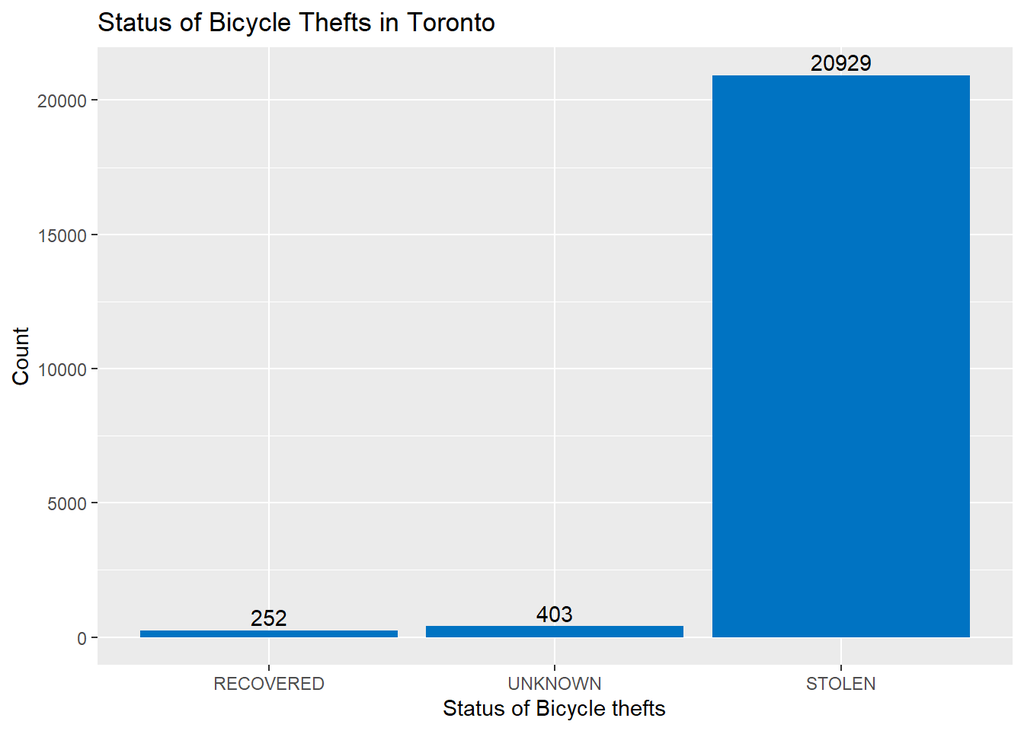

```r
status_df <- df %>%
  group_by(Status) %>%
  count(Status)
status_df$Status <- factor(status_df$Status, levels = status_df$Status[order(status_df$n)])
ggplot(status_df, aes(x=Status, y=n)) +
  geom_bar(fill = "#0073C2FF", stat = "identity") +
  geom_text(aes(label = n), vjust = -0.3) +
  ggtitle("Status of Bicycle Thefts in Toronto") +
  xlab("Status of Bicycle thefts") + ylab("Count")
```

The data shows that there have been over 200 successful recoveries which is not bad, but low compared to number of occurrences. A possible major factor of this is that not many riders use the registry. So when unregistered stolen bikes are recovered, police do not know who to return the bike to. Hence, this could also explain why there are over 400 cases in the “unknown” status. As such, Toronto Police strongly encourages people to register their bikes. There is no drawback in doing so, and logically speaking, this will increase the recovery rate.

### Understand the Setting

The next measure to take is to understand the setting of bike thefts. By being aware of when and where bike thefts often take place, owners will be more cautious in those settings and adjust their plans accordingly to ensure the safety of their bike. These settings include neighborhood, time of day, and location type. For the neighborhood plot, the Toronto Police Division number will be used. Toronto is divided up into sectors that are covered by one of these police divisions.

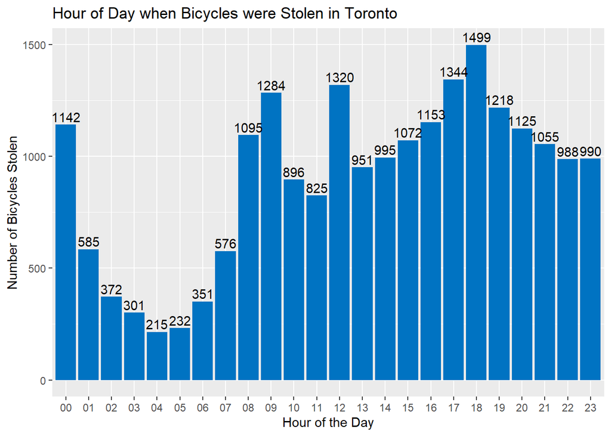

```r
# round down to the nearest hour
hour_floor_func <- function(x) substr(x, start = 1, stop = 2)
hour_floor <- data.frame(sapply(df$Occurrence_Time, hour_floor_func))
colnames(hour_floor)[1] <- "Occurrence_Hour"

hour_df <- hour_floor %>%
  group_by(Occurrence_Hour) %>%
  count(Occurrence_Hour)

ggplot(hour_df, aes(x=Occurrence_Hour, y=n)) +
  geom_bar(fill = "#0073C2FF", stat = "identity") +
  geom_text(aes(label = n), vjust = -0.3) +
  ggtitle("Hour of Day when Bicycles were Stolen in Toronto") +
  xlab("Hour of the Day") + ylab("Number of Bicycles Stolen")
```

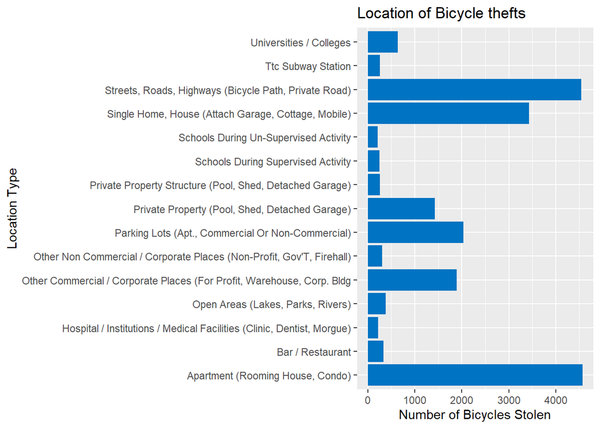

```r
location_type_df <- df %>%
  group_by(Location_Type) %>%
  count(Location_Type) %>%
  filter(n > 200)
ggplot(location_type_df, aes(x=Location_Type, y=n)) +
  geom_bar(fill = "#0073C2FF", stat = "identity") +
  ggtitle("Location of Bicycle thefts") +
  xlab("Location Type") + ylab("Number of Bicycles Stolen") + coord_flip()
```

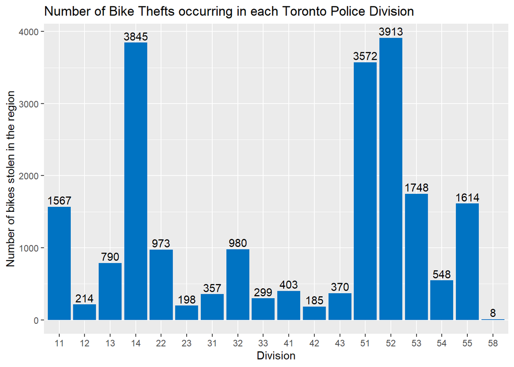

```r
division_df <- data.frame(sapply(df$Division, as.character))
colnames(division_df)[1] <- "Division"

division_count_df <- division_df %>%
  group_by(Division) %>%
  count(Division)

ggplot(division_count_df, aes(x=Division, y=n)) +
  geom_bar(fill = "#0073C2FF", stat = "identity") +
  geom_text(aes(label = n), vjust = -0.3) +
  ggtitle("Number of Bike Thefts occurring in each Toronto Police Division") +
  xlab("Division") + ylab("Number of bikes stolen in the region")
```

### Bicycle Features

For new riders or people looking for a new bike, it may be worth considering the paying attention to some features that are more susceptible to theft. Below is plot for the type, color, and manufacturer characteristics of stolen bikes:

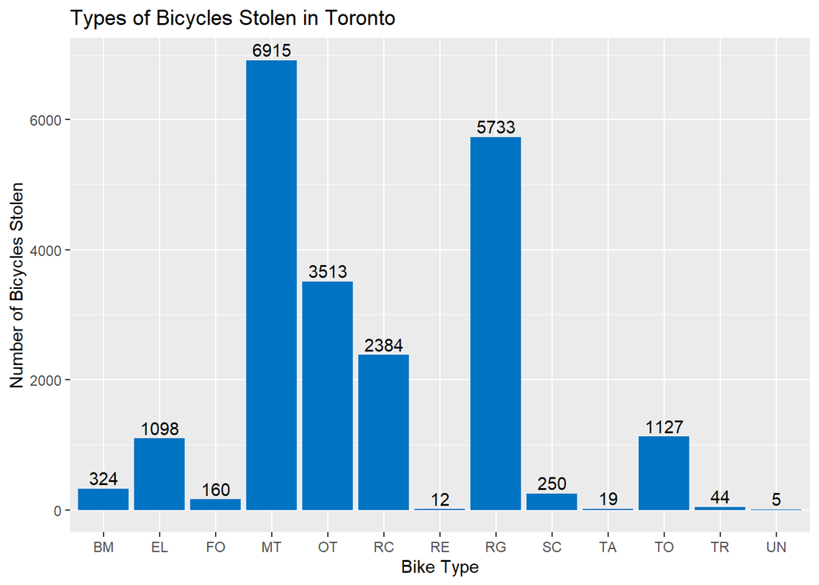

```r
bike_type_df <- df %>%
  group_by(Bike_Type) %>%
  count(Bike_Type)

ggplot(bike_type_df, aes(x=Bike_Type, y=n)) +
  geom_bar(fill = "#0073C2FF", stat = "identity") +
  geom_text(aes(label = n), vjust = -0.3) +
  ggtitle("Types of Bicycles Stolen in Toronto") +
  xlab("Bike Type") + ylab("Number of Bicycles Stolen")
```

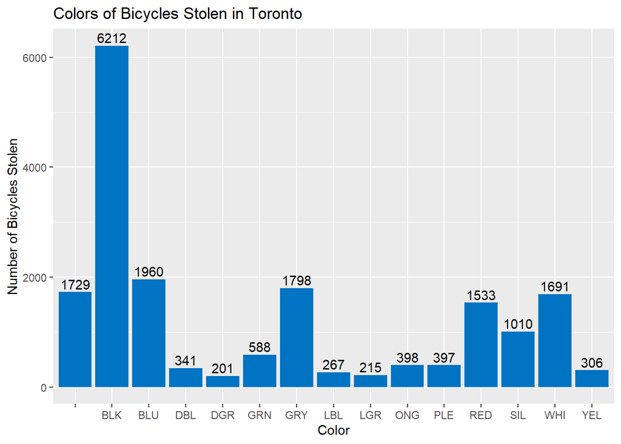

```r
color_df <- df %>%
  group_by(Bike_Colour) %>%
  count(Bike_Colour) %>%
  filter(n > 200)

ggplot(color_df, aes(x=Bike_Colour, y=n)) +
  geom_bar(fill = "#0073C2FF", stat = "identity") +
  geom_text(aes(label = n), vjust = -0.3) +
  ggtitle("Colors of Bicycles Stolen in Toronto") +
  xlab("Color") + ylab("Number of Bicycles Stolen")
```

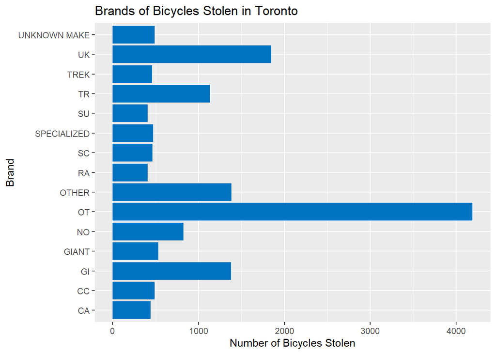

```r
make_df <- df %>%
  group_by(Bike_Make) %>%
  count(Bike_Make) %>%
  filter(n > 400)

ggplot(make_df, aes(x=Bike_Make, y=n)) +
  geom_bar(fill = "#0073C2FF", stat = "identity") +
  ggtitle("Brands of Bicycles Stolen in Toronto") +
  xlab("Brand") + ylab("Number of Bicycles Stolen") + coord_flip()
```

### Proper locking

Lastly, the final proactive measure is direct close-up prevention when a person is attempting theft. Even if the owner has followed all the tips described above, if the bike is not properly locked, it can be easily stolen. As a result, the owner should buy the appropriate locking tools for their bike. Typically, this would consist of a standard U-lock for the front wheel and frame and a heavy duty cable lock for the back wheel and frame. Additionally, avoid locking bikes on objects that can be removed and make sure to fasten the frames and wheels of the bike to the object. Try to use bike racks if possible and use them as directed (ie. lock the bike inside the rack, not beside the rack).

### Weaknesses and Next Steps

Throughout these observations, there are a few noticeable areas that require further background research and sampling in order to reach more convincing conclusions. To properly analyze the effectiveness of the bike registry on recovery rates, the bike registry dataset is required to know how many registered bikes were stolen/recovered. A survey could also be conducted to understand how many people register their bikes or are at least aware of it. Additionally, all of the bicycle feature graphs could be greatly supported by understanding what kinds of bikes that are owned by Torontonians (not only the ones that were stolen), so stronger observations could be made (eg. which features are more vulnerable to theft). Again, this could be achieved by getting the bike registry data or surveying the rider population.

To conclude, Toronto is currently constructing an amazing bike environment but has seen an increasing trend in bike thefts. The city has begun addressing this issue, but it is ultimately up to the riders to keep their bikes safe from theft as much as possible. To lower the chances of bike theft, riders should be mindful of settings that have high occurrences of bike theft. One important takeaway is to be be extra cautious when parking in any region near West Spadina as well as Yonge from South of Bloor. Ensure that bicycles are always securely fastened (U-lock on front wheel and frame, heavy duty cable on back wheel and frame) against a reliable bike rack or any other heavily grounded sturdy object. Furthermore, riders should register their bike with the Toronto Police as a verification of bike ownership to have a better recovery rate in the event that their bike gets stolen. If these tips implemented by the general population, Toronto can see a reduced number of thefts and people can enjoy the great bike riding experience that the city has to offer.

To see the full code, please visit the Githup repository [here](https://github.com/chenala/bike-theft-prevention/).

**References**

*City of Toronto. “2018 Cycling in Toronto.” City of Toronto, 4 Feb. 2020, www.toronto.ca/city-government/council/2018-council-issue-notes/cycling-in-toronto/.*

*City of Toronto. “Bike Theft Prevention.” City of Toronto, 5 June 2018, www.toronto.ca/services-payments/streets-parking-transportation/cycling-in-toronto/safety-and-education/bike-theft-prevention/.*